# R语言与机器学习（上）

### 过拟合与欠拟合的特征

| 特征 | 欠拟合 | 过拟合 |
| --- | --- | --- |
| 训练误差 | 高 | 低 |
| 测试误差 | 高 | 高 |
| 原因 | 模型太简单 | 模型太复杂 |
| 表现 | 学不到规律 | 记住噪声 |
| 解决方法 | 增加模型复杂度 | 正则化、增加数据、简化模型 |

```r
# 计算训练误差和测试误差
# 生成新数据作为测试集
set.seed(999)
x_test <- seq(-3, 3, length.out = 100)
y_test_true <- 0.5 * x_test^2 - 1
y_test <- y_test_true + rnorm(100, sd = 0.5)
test_data <- data.frame(x = x_test, y = y_test)

# 预测测试集
test_data$pred_underfit <- predict(model_underfit, newdata = test_data)
test_data$pred_good <- predict(model_good, newdata = test_data)
test_data$pred_overfit <- predict(model_overfit, newdata = test_data)

# 计算均方误差
calc_mse <- function(actual, predicted) {
  mean((actual - predicted)^2)
}

cat("欠拟合（线性）- 训练MSE:", calc_mse(poly_data$y, poly_data$pred_underfit), "测试MSE:", calc_mse(test_data$y, test_data$pred_underfit), "\n")
```

```
## 欠拟合（线性）- 训练MSE: 2.525686 测试MSE: 2.151376
```

```r
cat("适度拟合（二次）- 训练MSE:", calc_mse(poly_data$y, poly_data$pred_good), "测试MSE:", calc_mse(test_data$y, test_data$pred_good), "\n")
```

```
## 适度拟合（二次）- 训练MSE: 0.3484976 测试MSE: 0.2811028
```

```r
cat("过拟合（15阶）- 训练MSE:", calc_mse(poly_data$y, poly_data$pred_overfit), "测试MSE:", calc_mse(test_data$y, test_data$pred_overfit), "\n")
```

```
## 过拟合（15阶）- 训练MSE: 0.2188181 测试MSE: 0.4459991
```

### 如何判断过拟合/欠拟合？

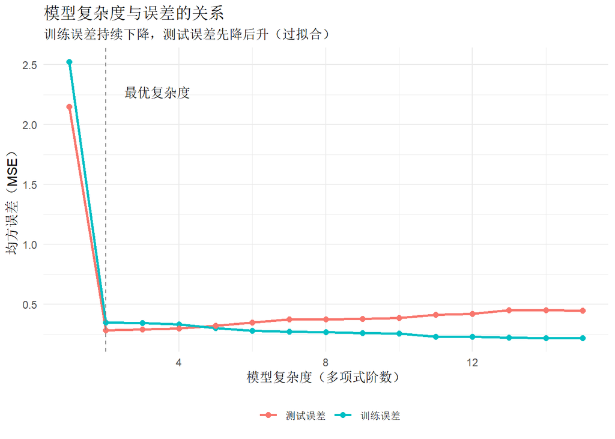

```r
# 模型复杂度与误差的关系图
# 模拟不同复杂度下的训练误差和测试误差

complexity <- 1:15
train_errors <- c()
test_errors <- c()

for (deg in complexity) {
  model <- lm(y ~ poly(x, degree = deg, raw = TRUE), data = poly_data)
  train_errors <- c(train_errors, calc_mse(poly_data$y, predict(model)))
  test_errors <- c(test_errors, calc_mse(test_data$y, predict(model, newdata = test_data)))
}

error_data <- data.frame(
  complexity = rep(complexity, 2),
  error = c(train_errors, test_errors),
  type = rep(c("训练误差", "测试误差"), each = length(complexity))
)

ggplot2::ggplot(error_data, ggplot2::aes(x = complexity, y = error, color = type)) +
  ggplot2::geom_line(linewidth = 1) +
  ggplot2::geom_point(size = 2) +
  ggplot2::geom_vline(xintercept = 2, linetype = "dashed", color = "gray50") +
  ggplot2::annotate("text", x = 2.5, y = max(error_data$error) * 0.9,
                    label = "最优复杂度", hjust = 0) +
  ggplot2::labs(
    title = "模型复杂度与误差的关系",
    subtitle = "训练误差持续下降，测试误差先降后升（过拟合）",
    x = "模型复杂度（多项式阶数）", y = "均方误差（MSE）", color = ""
  ) +
  ggplot2::theme_minimal() +
  ggplot2::theme(legend.position = "bottom")
```

### 解决方法

| 问题 | 解决方法 |
| --- | --- |
| 欠拟合 | 增加特征、使用更复杂模型、减少正则化 |
| 过拟合 | 增加训练数据、正则化、简化模型、早停、Dropout |

### 意义与使用场景

**核心意义**：过拟合和欠拟合是机器学习中最常见的问题，找到合适的模型复杂度是建模的关键。

**举例**：构建心脏病预测模型

**过拟合的场景**：

使用包含100个特征的深度神经网络，训练集准确率99%，但测试集只有65%。模型”记住”了训练集中每个患者的特殊情况，包括噪声和巧合。

**欠拟合的场景**：

使用简单的逻辑回归，只用年龄一个特征，训练集和测试集准确率都只有60%。模型太简单，无法捕捉疾病与多种因素之间的复杂关系。

**如何解决？**

过拟合：增加数据、使用正则化、简化模型（如减少层数）、特征选择。欠拟合：增加特征、使用更复杂的模型（如随机森林）、减少正则化强度。